# Dragon Phylogeny

Alyssa Green

2023-03-01

[Link to GitHub](https://github.com/alyssagreen02/BIOL432-Week7-DragonPhylogeny)

## Load library and read nexus file

```r
library(ape)
DragonNexus=read.nexus.data("DragonMatrix.nex")
head(DragonNexus)
```

```
## $`0.1FishXXX`
##  [1] "0" "0" "0" "0" "0" "0" "0" "0" "0" "0" "0" "0" "0" "0" "0" "0" "0" "0" "0"
## [20] "0" "0" "0" "0" "0" "0" "0" "0" "0" "0" "0" "0" "0" "0" "0" "0" "0" "0" "0"
## [39] "0" "0" "0" "0" "0" "0" "0" "0" "0" "0" "0" "0" "0" "0" "0" "0" "0" "0" "0"
## [58] "0" "0" "0" "0" "0" "0" "0" "0" "0" "0" "0" "0" "0" "0" "0" "0" "0" "0" "0"
## [77] "0" "0"
##
## $`0.2SnakeXX`
##  [1] "1" "1" "1" "1" "0" "0" "0" "0" "1" "1" "1" "0" "0" "1" "1" "1" "0" "1" "1"
## [20] "0" "0" "0" "0" "0" "0" "0" "1" "1" "0" "0" "0" "0" "0" "0" "1" "0" "0" "0"
## [39] "1" "0" "0" "0" "1" "0" "0" "0" "1" "0" "0" "0" "0" "0" "0" "1" "1" "1" "1"
## [58] "1" "1" "0" "0" "0" "0" "0" "0" "0" "0" "1" "0" "0" "0" "0" "0" "0" "0" "0"
## [77] "0" "0"
##
## $`0.3MammalX`
```

[output cut: 26 more lines]

## Code my dragons and add them to the nexus file

```r
P=list('1','0','0','1','1','1','1','1','0','1','0','0','1','0','0','1','1','0','0','0','0','1','0','0','0','0','0','1','1','0','0','1','1','0','0','0','0','0','0','0','0','1','1','0','?','?','?','?','?','?','0','0','0','1','0','0','0','0','0','0','0','1','1','1','0','0','0','0','0','0','1','0','0','1','1','0','1','0')

G=list('1','0','0','1','0','1','1','1','0','1','?','?','?','?','0','1','0','0','1','0','0','0','0','0','1','0','0','1','1','1','0','1','0','0','0','1','1','0','1','1','0','0','0','0','1','1','0','0','0','0','1','1','0','0','1','0','?','?','?','?','?','?','?','?','?','?','?','?','?','?','0','1','1','1','1','1','0','0')

R=list('1','0','1','0','0','1','1','1','1','0','0','0','0','0','1','1','0','0','0','0','0','0','0','1','0','0','1','1','0','1','0','0','0','0','0','0','1','0','0','0','1','1','0','0','0','0','0','0','1','1','0','0','0','0','0','?','?','?','?','0','1','0','0','0','0','0','?','?','?','0','0','0','1','1','0','0','1')



P=as.character(P)
G=as.character(G)
R=as.character(R)
PGR=list(P,G,R)
DragonNexusFinal=c(DragonNexus, PGR)


names(DragonNexusFinal)[78]="75PinkXXXX"
names(DragonNexusFinal)[79]="76GreenXXX"
names(DragonNexusFinal)[80]="77RainbowX"
```

## Export nexus file and save to input folder

```r
write.nexus.data(DragonNexusFinal, "./input/DragonNexusFinal.nexus")
```

## Convert nexus file to data frame

```r
DragonNexusDF=data.frame(matrix(unlist(DragonNexusFinal), ncol=78, byrow=T))
row.names(DragonNexusDF)=names(DragonNexusFinal)
head(DragonNexusDF)
```

```
##            X1 X2 X3 X4 X5 X6 X7 X8 X9 X10 X11 X12 X13 X14 X15 X16 X17 X18 X19
## 0.1FishXXX  0  0  0  0  0  0  0  0  0   0   0   0   0   0   0   0   0   0   0
## 0.2SnakeXX  1  1  1  1  0  0  0  0  1   1   1   0   0   1   1   1   0   1   1
## 0.3MammalX  1  0  0  0  0  0  0  0  0   0   1   1   1   0   0   0   0   0   0
## 1GermanXXX  0  1  0  0  1  1  1  0  0   1   1   1   1   0   0   0   0   1   1
## 2FrenchXXX  0  1  0  0  1  1  0  1  0   1   1   0   0   1   1   1   0   1   0
## 3FrenchXXX  0  1  0  0  1  1  1  0  0   0   1   1   0   0   0   0   0   0   ?
##            X20 X21 X22 X23 X24 X25 X26 X27 X28 X29 X30 X31 X32 X33 X34 X35 X36
## 0.1FishXXX   0   0   0   0   0   0   0   0   0   0   0   0   0   0   0   0   0
## 0.2SnakeXX   0   0   0   0   0   0   0   1   1   0   0   0   0   0   0   1   0
## 0.3MammalX   0   0   0   1   0   0   0   1   1   1   0   0   0   0   0   1   1
## 1GermanXXX   0   0   0   0   1   0   1   1   1   1   1   0   0   0   0   1   1
## 2FrenchXXX   0   0   0   0   0   0   1   1   1   1   1   0   0   0   0   1   1
## 3FrenchXXX   ?   ?   1   0   1   0   0   1   1   1   1   0   0   0   0   1   1
##            X37 X38 X39 X40 X41 X42 X43 X44 X45 X46 X47 X48 X49 X50 X51 X52 X53
## 0.1FishXXX   0   0   0   0   0   0   0   0   0   0   0   0   0   0   0   0   0
## 0.2SnakeXX   0   0   1   0   0   0   1   0   0   0   1   0   0   0   0   0   0
## 0.3MammalX   0   0   1   1   0   0   1   1   0   0   0   0   0   0   0   0   0
## 1GermanXXX   0   1   0   0   0   0   1   1   0   1   1   0   0   0   0   0   0
## 2FrenchXXX   0   0   1   0   0   0   1   1   0   0   0   0   0   0   0   0   0
## 3FrenchXXX   0   1   1   1   0   1   1   1   0   1   0   0   0   0   0   0   0
##            X54 X55 X56 X57 X58 X59 X60 X61 X62 X63 X64 X65 X66 X67 X68 X69 X70
## 0.1FishXXX   0   0   0   0   0   0   0   0   0   0   0   0   0   0   0   0   0
## 0.2SnakeXX   1   1   1   1   1   1   0   0   0   0   0   0   0   0   1   0   0
## 0.3MammalX   1   0   0   0   0   0   0   1   1   0   0   0   0   0   1   0   0
## 1GermanXXX   1   1   1   0   0   0   0   1   0   0   0   1   0   0   1   0   ?
## 2FrenchXXX   1   1   0   0   0   0   1   0   0   1   0   0   0   1   1   0   0
## 3FrenchXXX   1   1   1   0   0   0   0   1   0   0   0   1   0   0   1   0   0
##            X71 X72 X73 X74 X75 X76 X77 X78
## 0.1FishXXX   0   0   0   0   0   0   0   0
## 0.2SnakeXX   0   0   0   0   0   0   0   0
## 0.3MammalX   0   0   0   1   0   0   0   0
## 1GermanXXX   ?   ?   ?   0   0   1   1   1
## 2FrenchXXX   0   1   1   0   0   1   1   0
## 3FrenchXXX   0   1   1   0   0   1   1   1
```

## Input weights data

```r
weightsDat=read.csv("Weights.csv")
```

## create a single vector of weights

```r
Weights=paste0(weightsDat$Weight,collapse = "")
Weights=strsplit(Weights, split = "")[[1]]
```

## Convert each letter to a value

```r
WeightsNum=rep(NA,length(Weights))
for (i in 1:length(WeightsNum)) {
  if(Weights[i] %in% LETTERS){
    WeightsNum[i]=which(LETTERS==Weights[i])+9
  } else {
    WeightsNum[i]=Weights[i]
  }

}

WeightsNum=as.numeric(WeightsNum)
```

```r
length(WeightsNum)
```

```
## [1] 78
```

## Multiply weight value by the trait vector for each dragon

```r
WtDragonNexus=DragonNexusFinal
for (i in 1:length(DragonNexusFinal)) {
  RepWeight=DragonNexusFinal[[i]]==1
  WtDragonNexus[[i]][RepWeight]=WeightsNum[RepWeight]
  RepWeight=NA
}
```

## Calculate the distance matrix

```r
WtDragonNexusDF=data.frame(matrix(unlist(WtDragonNexus), ncol=78,byrow=T))
row.names(WtDragonNexusDF)=names(WtDragonNexus)
WtDragonDist=dist(WtDragonNexusDF, method = "euclidean")
```

## Images of Dragons

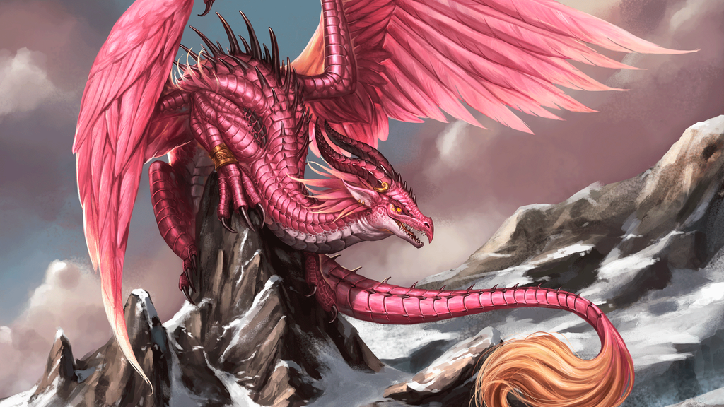

Citation: Classic Pink Dragon. (2019). Dragon Shield. Retrieved March 1, 2023, from https://twitter.com/dragonshield_/status/1186643372796268547.

[figure not shown]

Citation: Sandara. (2015). Green Dragon v2. Deviant Art. Retrieved March 1, 2023, from https://www.deviantart.com/sandara/art/Green-Dragon-v2-579637253.

[figure not shown]

Citation: Christou, A. (n.d.). Rainbow Dragon. A Christou Art. Retrieved March 1, 2023, from https://www.achristouart.com/rainbow-dragon.

## Plot Tree

```r
library(ggtree)
WtDragonTree=fastme.bal(WtDragonDist)
ggtree(WtDragonTree, layout="circular")
```

```
## ! The tree contained negative edge length. If you want to ignore the edge, you
## can set `options(ignore.negative.edge=TRUE)`, then re-run ggtree.
```

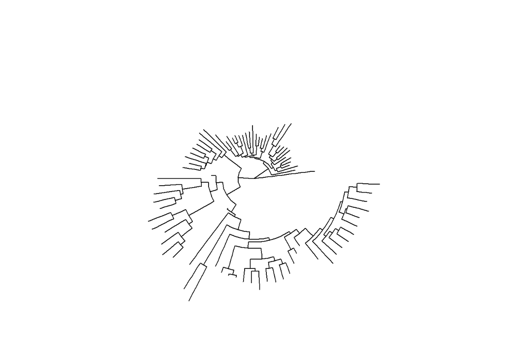

## Get tip labels by country

```r
Country=gsub("[0-9\\.]+([^X]+)x*","\\1", WtDragonTree$tip.label)
```

## Isolate tip labels for my dragons

```r
CountryGroups=split(WtDragonTree$tip.label, Country)
Groups=list(CountryGroups$PinkXXXX,CountryGroups$GreenXXX, CountryGroups$RainbowX)
names(Groups)[1]="75PinkXXXX"
names(Groups)[2]="76GreenXXX"
names(Groups)[3]="77RainbowX"
```

## Make plotting data

```r
WtDTcol=groupOTU(WtDragonTree, Groups)
```

```
## ! The tree contained negative edge length. If you want to ignore the edge, you
## can set `options(ignore.negative.edge=TRUE)`, then re-run ggtree.
```

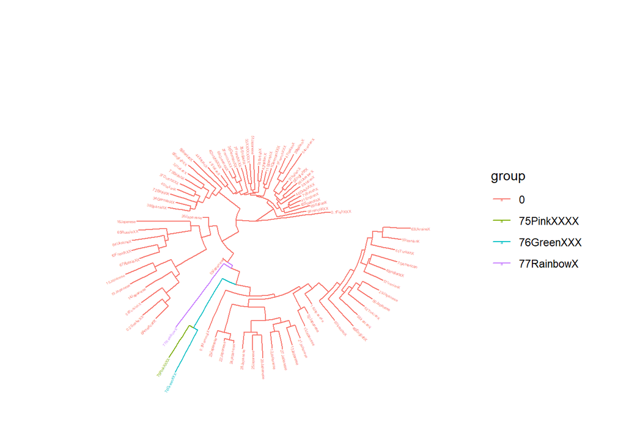

```r
ggtree(WtDTcol, layout="circular", aes(colour=group))+geom_tiplab(size=1, aes(angle=angle))
```

Figure 1: Dragon phylogeny. The phylogeny represents the relationship between dragons based on their phenotypic characteristics. The phylogeny is coloured coded to highlight the three added dragons, with blue for dragon 76GreenXXX, green for dragon 75PinkXXXX and purple for dragon 77RainbowX. The colour orange, labelled 0, denotes all other dragons.

## Backstory and Data Interpretation

The pink, green, and rainbow dragons are highly elusive and rarely witnessed. We collected data on these dragons’ phenotypic characteristics using documentation from rare civilian sightings. From this data, we created a phylogeny, mapping the pink, green, and rainbow dragons relative to those from the known dragon database. The information we received from this phylogeny was very intriguing. The pink, green, and rainbow dragons are members of the same clade, with the rainbow dragon deviating first from the ancestral population. The pink and green dragons deviated from the ancestral population after the rainbow dragon, simultaneously as one species, later diverging into separate species. The pink, green, and rainbow dragons are most similar to those known to originate from Japan and therefore are closely related to the Japanese dragons. The phylogeny also shows that the pink, green, and rainbow dragons are more closely related to the mammal outgroup than the fish and snake outgroups. This study is significant as it provides insight into our planet’s little-known species of dragons.